# ds202_hw5

1.The code below downloads the data for Ames only and saves a local copy to your machine. The first time you run this code, make sure you have a good internet connection and enough space on your machine (~50 MB). If the local copy exists, re-knitting the file will load the (binary) file from disk and be much faster.

```r
library(readr)
if (file.exists("alcohol.rds")) {
  data <- readRDS("alcohol.rds")
} else {
  url <- "https://xdaiisu.github.io/ds202materials/data/ames.csv"
  data <- readr::read_csv(url)
  saveRDS(data, file="alcohol.rds")
}
```

2.Data cleaning: ·extract geographic latitude and longitude from the variable Store Location ·check variable types. Pick five variables that need to be converted to a different type and fix those. ·extract year, month and day from the variable Date

```r
library(ggplot2)
library(dplyr)
library(tidyr)

dataClean <- readRDS("alcohol.rds")
dataClean <- suppressWarnings(separate(dataClean, "Store Location", c("Address", "Coordinates"), sep = "\\("))
dataClean <- separate(dataClean, "Coordinates", c("latitude", "longitude"), sep = ",")
dataClean<- separate(dataClean, "longitude", c("longitude", "empty"), sep = "\\)")
dataClean <- dataClean %>% select(-c("empty"))
dataClean$latitude <- as.numeric(dataClean$latitude)
dataClean$longitude <- as.numeric(dataClean$longitude)
dataClean$`Vendor Number` <- as.numeric(dataClean$`Vendor Number`)
dataClean$`Store Name` <- as.factor(dataClean$`Store Name`)
dataClean$`Category Name` <- as.factor(dataClean$`Category Name`)
dataClean <- dataClean %>% mutate("Real Date" = Date) %>% separate("Date", c("Month", "Day", "Year"), sep="/")
```

3.First overview: ·Plot a scatterplot of lat and long of store locations.

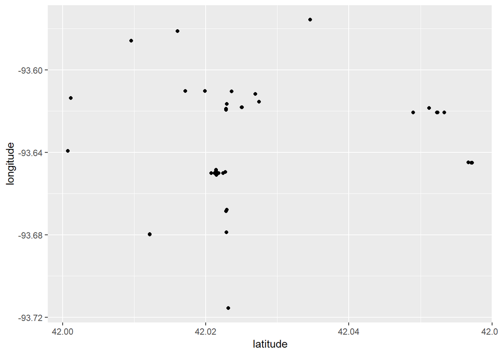

```r
data <- dataClean
suppressWarnings(ggplot(data, aes(x = latitude, y = longitude)) + geom_point())
```

·Provide a visual breakdown of the liquor category (by Category Name). Include volume sold in the breakdown.

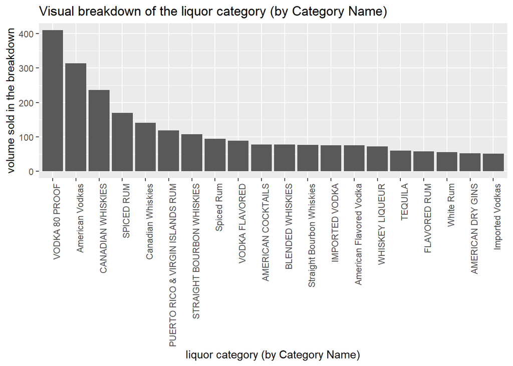

```r
visual <- suppressWarnings(data %>% group_by(`Category Name`) %>% summarise(total = (sum(`Volume Sold (Liters)`)/1000)))
visual <- visual[order(-visual$total), ]
visual <- head(visual, 20)
ggplot(visual, aes(x= reorder(`Category Name`, -total), y=total)) + geom_col() + theme(axis.text.x = element_text(angle = 90, hjust = 1)) + xlab("liquor category (by Category Name)") + ylab("volume sold in the breakdown") + ggtitle("Visual breakdown of the liquor category (by Category Name)")
```

4.Find the daily sales liquor sales in Ames in 2018. Summarize number of sales, volume of liquor sold and amount of money spent. Plot volume sold by day (use a scatterplot of volume by day and facet by month). Describe any patterns. Find the dates for ISU football home games in Fall 2018. Can you see a pattern?

```r
#Summarize number of sales, volume of liquor sold and amount of money spent.
sales2018 <- data %>% filter(Year == 2018)
sum2018 <- sales2018 %>% summarise(numSales = sum(sales2018$`Bottles Sold`), volLiquor = sum(sales2018$`Volume Sold (Gallons)`), amtMoney = sum(sales2018$`Sale (Dollars)`))
sum2018
```

```
## # A tibble: 1 x 3
##   numSales volLiquor amtMoney
##      <dbl>     <dbl>    <dbl>
## 1   500850   127845. 7263877.
```

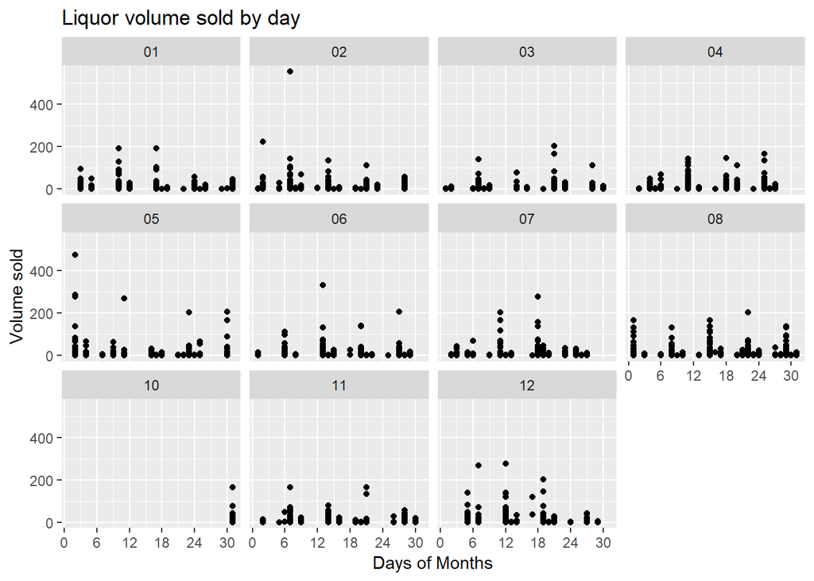

```r
#Plot volume sold by day (use a scatterplot of volume by day and facet by month).
sales2018$Day <- as.numeric(sales2018$Day)
ggplot(sales2018, aes(x=Day, y=`Volume Sold (Gallons)`)) + geom_point() + facet_wrap(~Month) + scale_x_continuous(breaks=seq(0,30,6)) + xlab("Days of Months") + ylab("Volume sold") + ggtitle("Liquor volume sold by day")
```

Find the dates for ISU football home games in Fall 2018: 9/1/18, 9/15/18, 9/22/18, 10/13/18, 10/27/18, 11/10/18, 11/24/18, 12/1/18

The football game mainly held in September to December. But we are missing the data in September and most October. The pattern cannot be told this time.